*Type your answers in the boxes. To run the R code, copy it into RStudio (use the Copy button on each code block). When you have finished, click **Download my answers** or use **Print / save as PDF**.*

# Spatial models

Practical session: MSc in Modelling for Global Health

**How to use this document.** Work through the tasks in order and run the code chunks interactively in RStudio (use the green arrow on each chunk). Chunks are not run automatically when you knit. Write your answers in the boxes marked “Your answer” (in the `.Rmd` file, type underneath that line). Packages needed: `deSolve`, `igraph` and `plot.matrix`. For Part 2 you will also need the files `movement_spatial.csv` and `pop_spatial.csv` in your working directory.

```r
library(deSolve)
library(igraph)
library(plot.matrix)
```

# Part 1: Two connected populations

Let’s consider a setting where two populations are connected by migration rates given by $f_{ij}$.

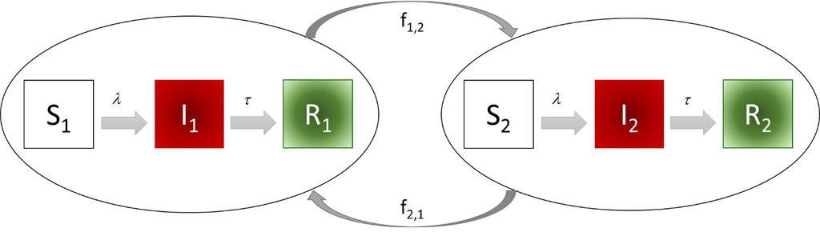

Two populations, each with susceptible (S), infected (I) and recovered (R) individuals, connected by migration flows $f_{1,2}$ and $f_{2,1}$.

Such a system can be expressed mathematically in R as follows. The model includes a transmission-blocking intervention in population 1, which starts at time `tbit` and reduces transmission by a fraction `tbeff`. By default `tbit` is set to a very large number, so the intervention never starts.

```r
SIR_patch <- function(t, state, parameters) {
  with(as.list(c(state, parameters)), {

    P1 <- S1 + I1 + R1
    P2 <- S2 + I2 + R2

    # force of infection; population 1 has a transmission-blocking
    # intervention that starts at time tbit
    lam1 <- beta1 * (1 - tbeff * (t >= tbit)) * I1 / P1
    lam2 <- beta2 * I2 / P2

    dS1 <- mu*P1 - mu*S1 - lam1*S1 - f12*S1 + f21*S2
    dI1 <- lam1*S1 - tau*I1 - mu*I1 - f12*I1 + f21*I2
    dR1 <- tau*I1 - mu*R1 - f12*R1 + f21*R2

    dS2 <- mu*P2 - mu*S2 - lam2*S2 + f12*S1 - f21*S2
    dI2 <- lam2*S2 - tau*I2 - mu*I2 + f12*I1 - f21*I2
    dR2 <- tau*I2 - mu*R2 + f12*R1 - f21*R2

    N <- P1 + P2

    list(c(dS1, dI1, dR1, dS2, dI2, dR2, N))
  })
}
```

The state variables and parameters are defined as:

```r
initP1 <- 1000
initI1 <- 1
initR1 <- 0
initS1 <- initP1 - initI1 - initR1

initP2 <- 1000
initR2 <- 0
initI2 <- 0
initS2 <- initP2 - initI2 - initR2

istate <- c(S1 = initS1, I1 = initI1, R1 = initR1,
            S2 = initS2, I2 = initI2, R2 = initR2,
            N = initS1 + initI1 + initR1 + initS2 + initI2 + initR2)

parameters <- c(
  mu    = 1 / (50 * 52 * 7),
  beta1 = 0.75,
  beta2 = 0.45,
  tau   = 1 / 10,
  f12   = 0.001,
  f21   = 0.001,
  tbit  = 1e100,   # start time of the intervention (never, by default)
  tbeff = 0.2      # effectiveness of the intervention
)
```

For a timeframe of

```r
time_start <- 0
time_stop  <- 100
deltat     <- 0.001
tps <- seq(time_start, time_stop, by = deltat)
```

run the ODE system defined by the `SIR_patch` function.

```r
out <- deSolve::ode(y = istate, times = tps, func = SIR_patch, parms = parameters)
plot(out)
```

## Task 1.1: Is the population size constant?

Check that the population size is constant. In the model function, `N` is expressed as the sum of `P1` and `P2`, and it is listed among the values returned to the ODE solver. **Why do you think the bottom row panels you get when running `plot(out)` show those numbers?**

Your answer: Task 1.1

## Task 1.2: Post-processing

Use the post-processing approach you used last week to check the population size in the `out` object.

```r
tail(rowSums(out[, 2:4])) + tail(rowSums(out[, 5:7]))
```

```
## [1] 2000 2000 2000 2000 2000 2000
```

## Task 1.3: What does `list()` do?

Interpret what the `list` function inside the `SIR_patch` function does. Interpretation can be aided by adding a counter to the output list:

```r
SIR_patch <- function(t, state, parameters) {
  with(as.list(c(state, parameters)), {

    P1 <- S1 + I1 + R1
    P2 <- S2 + I2 + R2

    lam1 <- beta1 * (1 - tbeff * (t >= tbit)) * I1 / P1
    lam2 <- beta2 * I2 / P2

    dS1 <- mu*P1 - mu*S1 - lam1*S1 - f12*S1 + f21*S2
    dI1 <- lam1*S1 - tau*I1 - mu*I1 - f12*I1 + f21*I2
    dR1 <- tau*I1 - mu*R1 - f12*R1 + f21*R2

    dS2 <- mu*P2 - mu*S2 - lam2*S2 + f12*S1 - f21*S2
    dI2 <- lam2*S2 - tau*I2 - mu*I2 + f12*I1 - f21*I2
    dR2 <- tau*I2 - mu*R2 + f12*R1 - f21*R2

    N <- P1 + P2
    count <- 1

    list(c(dS1, dI1, dR1, dS2, dI2, dR2, N, count))
  })
}
```

Remember to include the new variable in the initial conditions and set it to zero. Re-run the model and check the value in the `count` column (the 9th column of the output):

```r
tail(out[, 9], 1)
```

```
## [1] 100
```

Your answer: Task 1.3

## Task 1.4: What if movement stops?

Note that movement was set to be symmetrical (the same in and out flows for each area/population). **What would happen if individuals stopped moving from area 1 to area 2 altogether?** As in the previous week, we can re-set one (or more) parameters and re-run the call to the ODE solver:

```r
parameters["f12"] <- 0.0

out_no_migration <- deSolve::ode(y = istate, times = tps, func = SIR_patch, parms = parameters)
plot(out_no_migration)
```

What do you observe? Relate it to the initial conditions of the system. Change them to ensure you have an outbreak in population 2.

Your answer: Task 1.4

## Task 1.5: Knock-on effects of an intervention

Could interventions in one place have a knock-on effect on the other area? Let’s re-set the migration patterns and change the force of infection in region 1. We can do this by changing the time at which a transmission-blocking intervention with 20% effectiveness starts. If it is started at day 10:

```r
parameters["f12"]   <- 0.001
parameters["tbit"]  <- 10
parameters["tbeff"] <- 0.2

out_intervention <- deSolve::ode(y = istate, times = tps, func = SIR_patch, parms = parameters)

par(mfrow = c(2, 1))
plot(out[, 3], type = "l", col = "orange3", main = "Pop1")
lines(out_intervention[, 3], type = "l", col = "blue")
legend("topright", legend = c("Control", "Intervention"), lwd = 2,
       col = c("orange3", "blue"))

plot(out[, 6], type = "l", col = "orange3", main = "Pop2")
lines(out_intervention[, 6], type = "l", col = "blue")
```

You should observe something like the figure below.

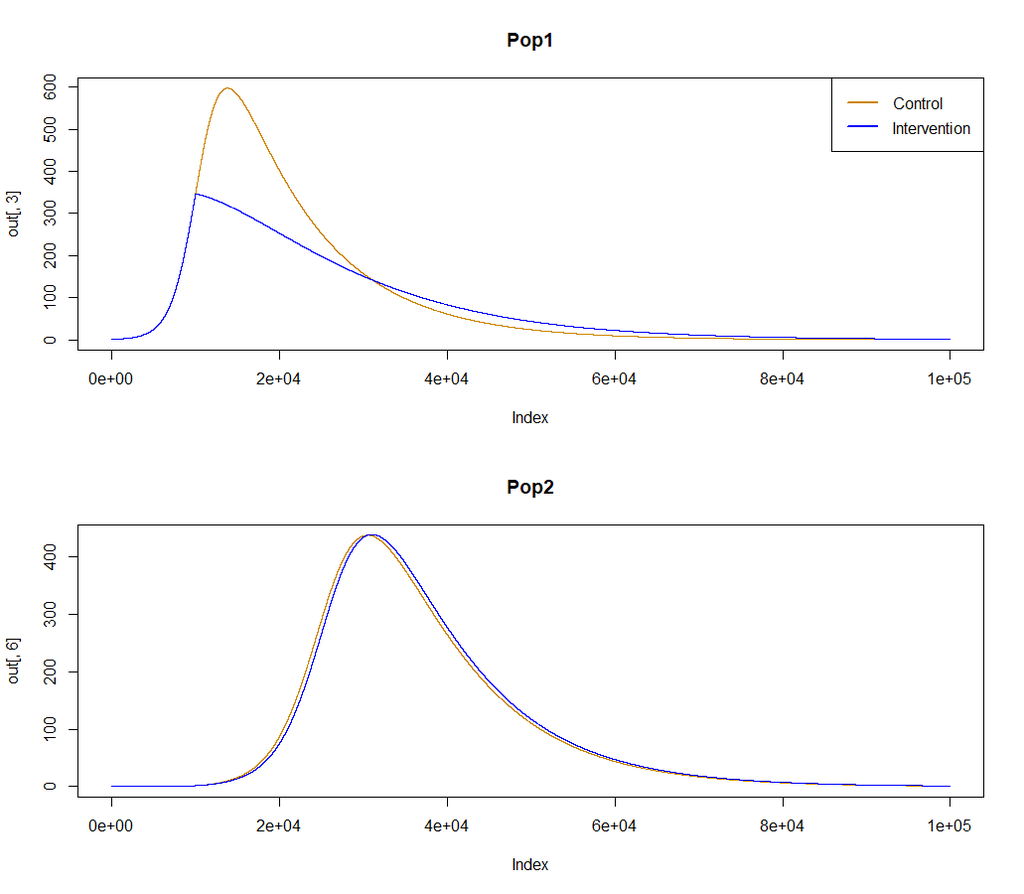

Infected individuals in each population, with and without the intervention in population 1.

Your answer: Task 1.5

## Task 1.6: Sensitivity analysis

Explore how sensitive these results are to:

1. the initial conditions of the system;
2. the relative difference in force of infection between the two areas;
3. the migration rate between Pop 1 and Pop 2.

Your answer: Task 1.6

You can start with the following:

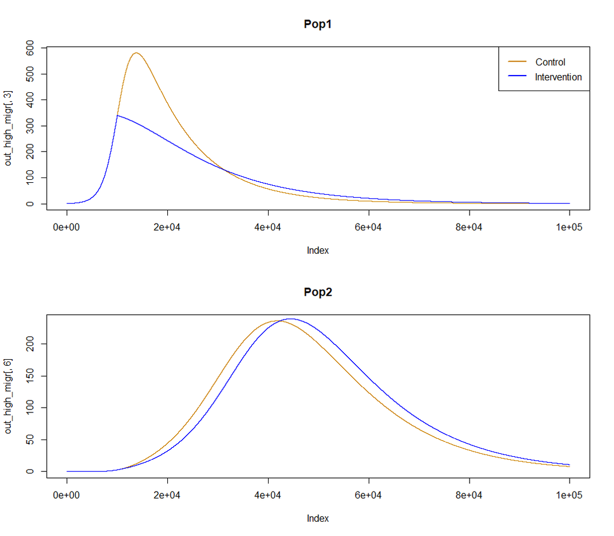

Expected output with higher migration from Pop 1 to Pop 2 and a lower transmission rate in Pop 2.

```r
parameters["tbit"]  <- 1e100
parameters["f12"]   <- 0.003
parameters["f21"]   <- 0.001
parameters["beta2"] <- 0.25

out_high_migr <- deSolve::ode(y = istate, times = tps, func = SIR_patch, parms = parameters)

parameters["tbit"] <- 10
out_intervention_high_migr <- deSolve::ode(y = istate, times = tps, func = SIR_patch, parms = parameters)

par(mfrow = c(2, 1))
plot(out_high_migr[, 3], type = "l", col = "orange3", main = "Pop1")
lines(out_intervention_high_migr[, 3], type = "l", col = "blue")
legend("topright", legend = c("Control", "Intervention"), lwd = 2,
       col = c("orange3", "blue"))

plot(out_high_migr[, 6], type = "l", col = "orange3", main = "Pop2")
lines(out_intervention_high_migr[, 6], type = "l", col = "blue")
```

## Task 1.7: A subcritical population

What if $R_0$ in Pop 2 is set to 0.1? **Would you still see an outbreak in Pop 2 given those migration patterns?**

*Hint: in this model $R_0 = \beta / (\tau + \mu)$.*

Your answer: Task 1.7

# Part 2: A scalable framework that takes in mobility data

In some circumstances we can access mobility data that inform the network of population migration patterns across large populations. In a new script, import the `movement_spatial` csv file, which describes the frequency and direction of population migration events in an area with 16 sub-populations, into R. Plot the matrix using the `plot.matrix` library.

```r
movement <- as.matrix(read.csv("movement_spatial.csv", header = FALSE))
movement <- movement * 0.00002
plot(movement)
```

Demographic information for each population can be found in the `pop_spatial` csv file.

```r
# Population structure
popstruc <- as.data.frame(read.csv("pop_spatial.csv", header = TRUE))
pop_size <- popstruc$pop
pop_x    <- popstruc$longitude
pop_y    <- popstruc$latitude
areas    <- length(pop_size)
```

This includes the population size of each sub-population, its x-y coordinates and the daily incidence per 100 people per day.

```r
# Spatial risk data
risk <- popstruc$incidence * 100
```

Using the `movement` object above, we can create a network reflecting the level of mobility between sub-populations. To do so, we use the `graph.adjacency` function in the `igraph` library. For a better visualisation, we highlight sub-populations with high daily incidence in red and make the size of the vertices proportional to the population size. Note that the relative positions of the nodes in this graph are fixed according to the x-y coordinates.

```r
# Visualise network
X <- as.matrix(movement)
g2 <- graph.adjacency(X, mode = "undirected", weighted = TRUE, diag = FALSE)

# Assign attributes to the graph
g2$name <- "SEIR spatial model"

# Assign attributes to the graph's vertices
V(g2)$color <- ifelse(risk > 0.5, "red", "green")
V(g2)$x     <- pop_x
V(g2)$y     <- pop_y
V(g2)$size  <- pop_size / 5e4

plot(g2, edge.width = E(g2)$weight * 8)
```

## Model set-up

We can initialise our metapopulation model with the following parameters.

```r
startdate <- as.Date("2023-01-01")
stopdate  <- as.Date("2023-12-31")
day_start <- as.numeric(startdate - startdate)
day_stop  <- as.numeric(stopdate - startdate)
times <- seq(day_start, day_stop)
```

```r
# MODEL PARAMETERS
parameters <- c(
  p      = 0.047,           # probability of infection given a contact
  rho    = 0.2,             # relative infectiousness of incubation phase
  omega  = 1 / (100 * 365), # rate of loss of immunity = 1 / (average duration of immunity)
  gamma  = 1 / 4.5,         # rate of movement from incubation to infectious stage = 1 / (average incubation period)
  nui    = 1 / 5,           # rate of recovery = 1 / (average duration of symptomatic infection phase)
  report = 1 / 8,           # proportion of all infections that are reported
  ratem  = 1 / 7,           # 1 / time to death for fatal
  nus    = 1 / 7,           # rate of recovery for non-fatal severe
  rhos   = 0.1,             # relative infectiousness * contacts of severely ill patients
  csr    = 0.1,             # case severity ratio
  sfr    = 0.2,             # severe case fatality ratio
  mort   = 1 / (80 * 365)   # mortality rate
)
```

How can we initialise the state variables of a metapopulation SEIR system? Try doing it by using indices, in the same way you saw it done for age-dependent models (more on this in the age-dependent model session).

Your answer: Initialising the state variables

```r
# Define the indices for each variable
Sindex  <- 1 : areas
Eindex  <- (areas + 1) : (2 * areas)
Iindex  <- (2 * areas + 1) : (3 * areas)
Rindex  <- (3 * areas + 1) : (4 * areas)
Hindex  <- (4 * areas + 1) : (5 * areas)
Mindex  <- (5 * areas + 1) : (6 * areas)
Cindex  <- (6 * areas + 1) : (7 * areas)
CMindex <- (7 * areas + 1) : (8 * areas)
```

```r
# MODEL INITIAL CONDITIONS
initI  <- round(0.01 * popstruc$pop)  # Infected and symptomatic
initE  <- 0 * popstruc$pop            # Incubating
initR  <- 0 * popstruc$pop            # Immune
initH  <- 0 * popstruc$pop            # Hospitalised
initM  <- 0 * popstruc$pop            # Died
initC  <- 0 * popstruc$pop            # Cumulative cases (true)
initCM <- 0 * popstruc$pop            # Cumulative deaths (true)
initS  <- popstruc$pop - initE - initI - initR - initH - initM  # Susceptible (non-immune)

# Initial conditions for the main solution vector (same order as the indices above)
Y <- c(initS, initE, initI, initR, initH, initM, initC, initCM)
```

## The spatial model

Now run your spatial model, taking special care to define the force of infection and the migration terms appropriately.

```r
# Set up a function to solve the equations
spatial_model <- function(t, Y, parameters) {
  with(as.list(c(Y, parameters)), {

    S  <- Y[Sindex]
    E  <- Y[Eindex]
    I  <- Y[Iindex]
    R  <- Y[Rindex]
    H  <- Y[Hindex]
    M  <- Y[Mindex]
    C  <- Y[Cindex]
    CM <- Y[CMindex]

    # print(t)
    contacts <- risk
    # print(contacts)

    P <- (S + E + I + R + H + M)

    lam <- p * contacts * ((rho * E + I + rhos * H) / P)
    # print(lam)
    # print(movement)

    dSdt <- - S * lam + omega * R - mort * S + mort * P -
      movement %*% S + t(movement) %*% S
    dEdt <- S * lam - gamma * E - mort * E -
      movement %*% E + t(movement) %*% E
    dIdt <- gamma * (1 - csr) * E - nui * I - mort * I -
      movement %*% I + t(movement) %*% I
    dRdt <- nui * I - omega * R - mort * R + nus * H -
      movement %*% R + t(movement) %*% R
    dHdt <- - mort * H + gamma * csr * (1 - sfr) * E - nus * H
    dMdt <- gamma * csr * sfr * E - ratem * M - mort * M

    dCdt  <- report * gamma * E
    dCMdt <- ratem * M + mort * M

    # return the rate of change
    list(c(dSdt, dEdt, dIdt, dRdt, dHdt, dMdt, dCdt, dCMdt))
  })
}
```

```r
# Run the model
out <- ode(y = Y, times = times, func = spatial_model, parms = parameters)

# Total population
pop <- out[, (Sindex + 1)] + out[, (Eindex + 1)] + out[, (Iindex + 1)] +
       out[, (Rindex + 1)] + out[, (Hindex + 1)] + out[, (Mindex + 1)]
tpop <- rowSums(pop)
plot(tpop)
```

## Tasks

**Task 2.1.** Uncomment some of the `print` statements above and re-run the code to check that the quantities make sense. How is the force of infection taking population movement into account?

Your answer: Task 2.1

**Task 2.2.** Does the total population plot make sense? Explain how we arrive at that number given the code structure and parameter values.

Your answer: Task 2.2

**Task 2.3.** Look at how population movement is implemented. What do these terms represent? Explain the formula conceptually.

```r
movement %*% S + t(movement) %*% S
```

Your answer: Task 2.3

**Task 2.4.** Report daily case incidence (given the reporting rate), hospital bed requirement over time and cumulative mortality.

Your answer: Task 2.4

**Task 2.5.** Plot cumulative mortality for each sub-population.